# Model fit diagnostics

```r
library(stockplotr)
```

Integrated assessment models such as FIMS and Stock Synthesis are fit to many data sources at once, including landings and fishery and survey indices of abundance. {stockplotr} has a set of diagnostic plots for these fits that work the same way for each model. They are based on the figures from r4ss and on diagnostics from JABBA and ss3diags.

| Diagnostic | Function | What it shows | Equivalent in other packages |
| --- | --- | --- | --- |
| Data availability | `plot_data_availability()` | Which data are available for each fleet and year | r4ss: `SSplotData()` |
| Index fit | `plot_index_fit()` | Observed indices with intervals and the expected index | r4ss: `SSplotIndices()` subplots 2 and 5 |
| Observed vs. expected | `plot_index_obs_exp()` | Whether indices are proportional to modeled abundance | r4ss: `SSplotIndices()` subplots 3 and 6 |
| All indices | `plot_index_overlay()` | Conflicting trends among indices | r4ss: `SSplotIndices()` subplot 9 |
| Landings fit | `plot_landings_fit()` | Observed and expected landings | r4ss: `SSplotCatch()` |
| Runs tests | `plot_runs_test()` | Non-random residuals and outliers | ss3diags: `SSplotRunstest()`; JABBA |
| Joint residuals | `plot_joint_residuals()` | Patterns shared among fleets, and RMSE | ss3diags: `SSplotJABBAres()`; JABBA |

## Input data

Each function takes the output of a model directly:

- **FIMS**: the output of `FIMS::get_estimates()` (on its own or passed through `convert_output()`), or the `FIMSFit` object itself. FIMS reports years as indices (1 = first model year), so use `start_year` to label the x-axis with years.
- **Stock Synthesis**: the output of `convert_output()`, or the list returned by `r4ss::SS_output()`.
- **Other models**: the output of `convert_output()`, or a tidy data frame (see `?prepare_fit_data`).

Indices and landings are first reshaped with `prepare_fit_data()`, which returns the observed and expected values, the observation error, and the residuals. Call it directly to inspect the data behind any of the plots:

```r
fits <- prepare_fit_data(example_data)
head(fits)
```

```
#> # A tibble: 6 x 11
#>   data_type fleet      year observed expected    se distribution used  residual
#>   <chr>     <chr>     <dbl>    <dbl>    <dbl> <dbl> <chr>        <lgl>    <dbl>
#> 1 index     Triennial  1980    1835     3323. 0.381 log_normal   TRUE   -0.594
#> 2 index     Triennial  1983    1968.    2438. 0.343 log_normal   TRUE   -0.214
#> 3 index     Triennial  1986    1819.    2212. 0.345 log_normal   TRUE   -0.196
#> 4 index     Triennial  1989    2590.    2178. 0.338 log_normal   TRUE    0.173
#> 5 index     Triennial  1992    1861.    1933. 0.339 log_normal   TRUE   -0.0384
#> 6 index     Triennial  1995    2071.    2517. 0.350 log_normal   TRUE   -0.195
#> # i 2 more variables: std_residual <dbl>, loglike <dbl>
```

The examples below use the Stock Synthesis model in `example_data`. The same calls work for FIMS; for example, with the FIMS example model:

```r
data("estimates_big_optimized", package = "FIMS")
fims <- estimates_big_optimized
plot_data_availability(fims, start_year = 2001)
plot_index_fit(fims, start_year = 2001)
plot_runs_test(fims, data_type = c("index", "landings"), start_year = 2001)
```

## What data are in the model?

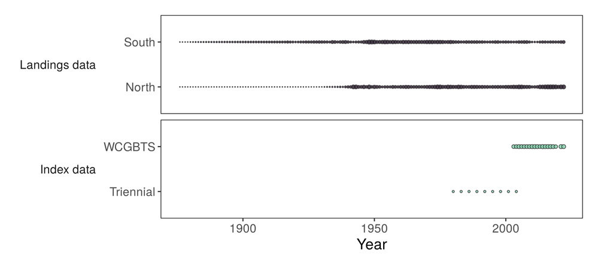

```r
plot_data_availability(example_data)
```

Point sizes are relative within each data type: landings by the amount landed and indices by their precision (1 / SE).

## Fits to indices and landings

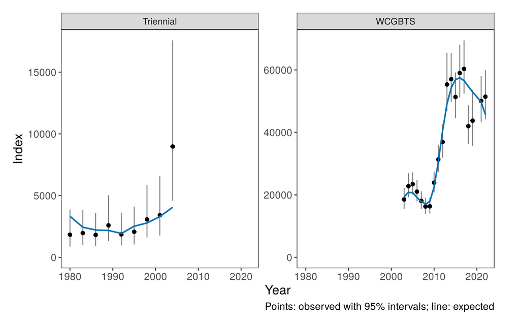

```r
plot_index_fit(example_data)
```

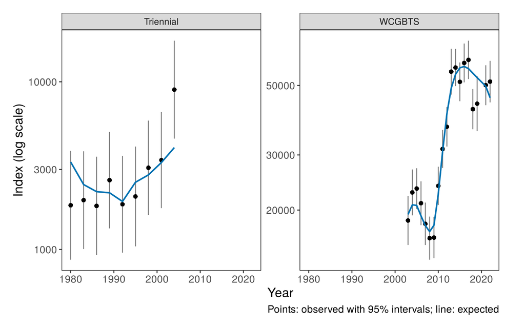

```r
plot_index_fit(example_data, log = TRUE)
```

Indices with lognormal errors are often easier to judge on a log scale, where the intervals are symmetric. Plotting observed against expected values shows whether the index is proportional to the modeled abundance; a smoother with a slope less than one suggests hyperstability:

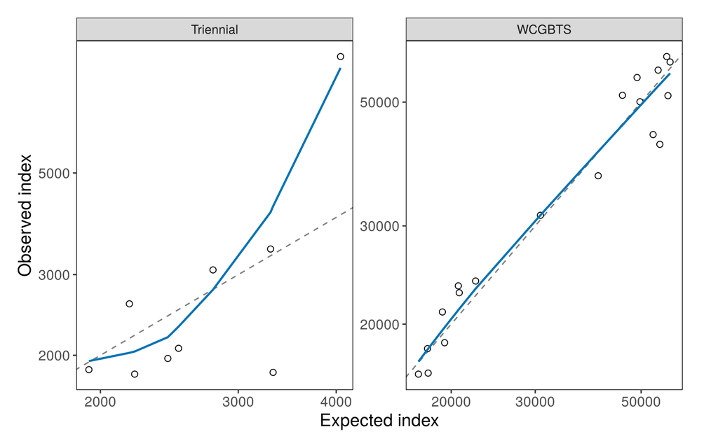

```r
plot_index_obs_exp(example_data)
```

Plotting all indices relative to their means shows whether they tell the same story:

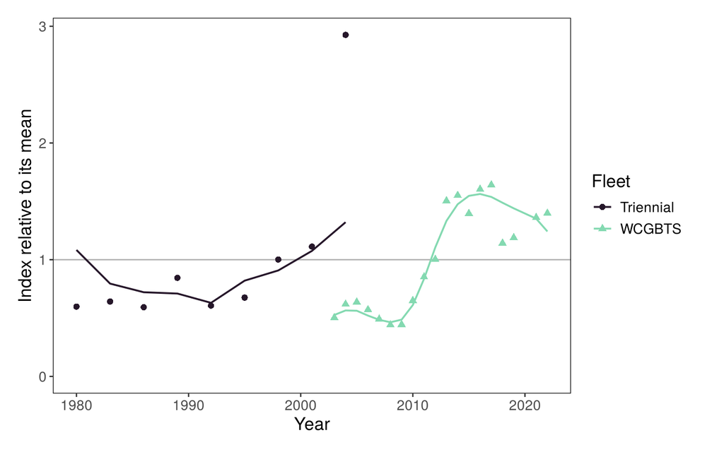

```r
plot_index_overlay(example_data)
```

Landings are usually fit closely; large residuals indicate a problem.

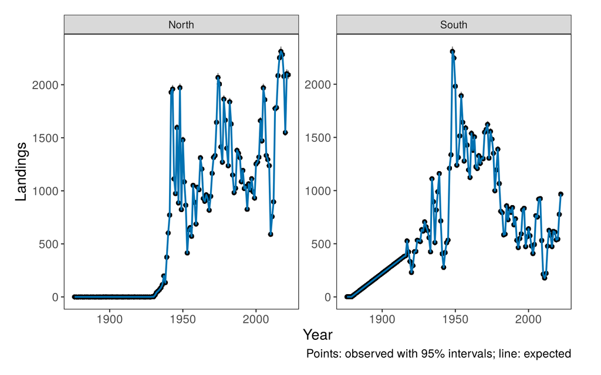

```r
plot_landings_fit(example_data)
```

## Residual diagnostics

### Runs tests

The runs test checks whether residuals are randomly positive and negative over time, and the three-sigma control limits flag outliers (Carvalho et al. 2017). The shaded band is green when the test passes and red when the residuals are not random:

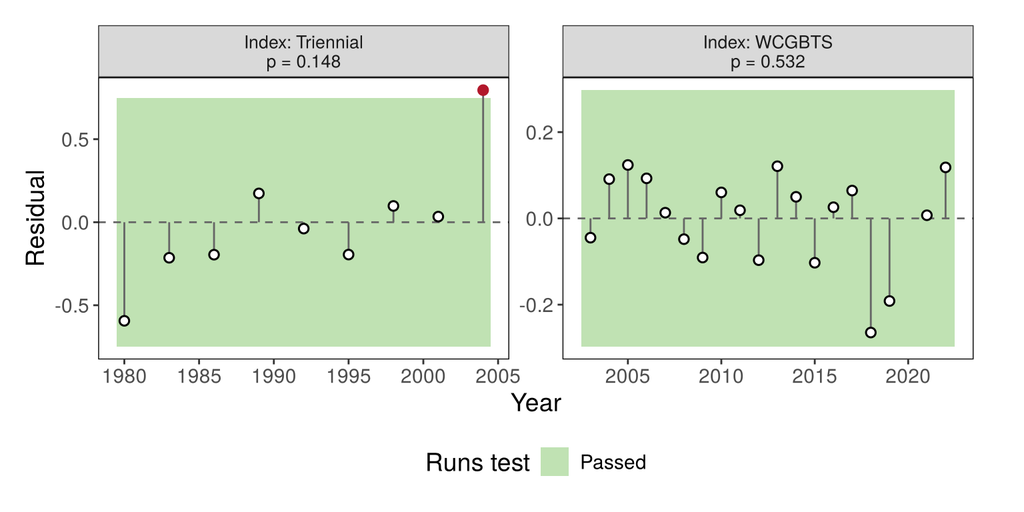

```r
plot_runs_test(example_data)
```

Here the last Triennial survey observation (2004) is outside the control limits.

### Joint residuals

Plotting the residuals of all fleets together, as in JABBA, shows years in which all data sources are above or below the model, and the root-mean-square error (RMSE) summarizes the overall fit:

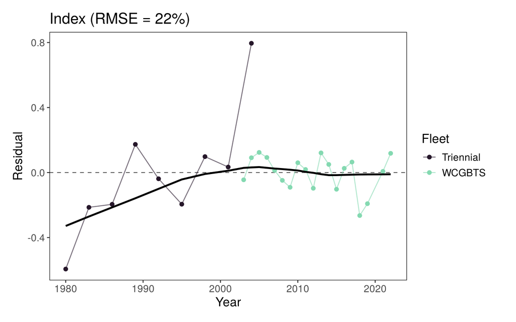

```r
plot_joint_residuals(example_data)
```

## References

Carvalho, F., Punt, A.E., Chang, Y.-J., Maunder, M.N., and Piner, K.R. 2017. Can diagnostic tests help identify model misspecification in integrated stock assessments? Fisheries Research 192: 28-40.

Carvalho, F., et al. 2021. A cookbook for using model diagnostics in integrated stock assessments. Fisheries Research 240: 105959.

Winker, H., Carvalho, F., and Kapur, M. 2018. JABBA: Just Another Bayesian Biomass Assessment. Fisheries Research 204: 275-288.